# Check Point #015

@codedtrader

2025-08-10

# **Crypto Weekly Intelligence Brief**

*“Your Retirement, Reimagined: Trump’s Executive Order Unlocks Crypto in 401(k)s—Ready to Ride the Wave?”*

[figure not shown]

Source: https://x.com/WatcherGuru/status/1953551088671404313

### **Macro Insight: Jerome Powell’s Potential Replacement and Cryptocurrency Inclusion in 401(k) Plans**

Last week, significant developments emerged with the potential replacement of Jerome Powell by Christopher Waller as Federal Reserve Chair, as highlighted by https://x.com/DariusDale42 of 42 Macro. Simultaneously, President Trump signed an executive order expanding 401(k) investment options to include cryptocurrencies, private equity, and real estate. These changes, as noted by official government accounts and macro analysts, could reshape monetary policy and retirement investment strategies, introducing both opportunities and risks.

Our extensive research indicates that Waller’s forecast-driven approach contrasts with Powell’s data-dependent strategy, potentially leading to market adjustments not yet priced in. The executive order on 401(k)s, while opening new avenues for diversification, raises concerns about asset quality and investor exposure, as evidenced by institutional struggles with private equity. These implications suggest increased market volatility and a need for reevaluation of investment risk.

In conclusion, these developments underscore the dynamic and challenging market conditions. Our research emphasizes the importance of a systematic approach to navigate these changes. We recommend staying informed, diversifying cautiously, and utilizing risk management tools like our proprietary SigmaSync Oscillator. Prioritizing extensive research and strategic planning will be crucial for investors to mitigate risks and capitalize on opportunities in this evolving landscape.

### **Crypto Market Conditions**

The crypto market is currently buzzing with activity, showing signs of strong growth and investor enthusiasm. Ethereum is leading the charge, with prices climbing higher and more people jumping into the trend. This excitement is fueled by recent developments, including potential changes at the Federal Reserve and new investment opportunities in retirement funds. These changes are creating a backdrop of increased investor confidence and market volatility, which our research suggests is influencing crypto price dynamics.

According to our extensive research of on-chain indicators, several key trends support the recent surge in crypto prices:

- Short-Term Holder Sell-Side Risk Ratio

This indicator shows that short-term investors are selling less, which means fewer people are quickly cashing out their crypto. Despite this drop in selling pressure, Bitcoin’s price has risen sharply, indicating strong buying interest from long-term holders or new entrants, aligning with the broader market’s bullish bias.

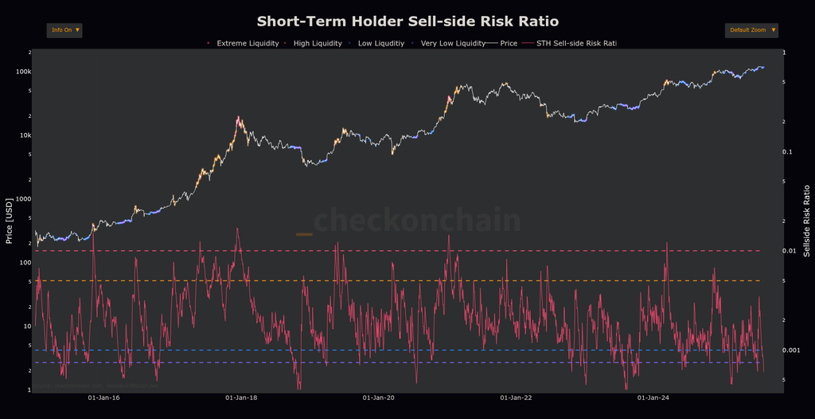

Source: https://charts.checkonchain.com/btconchain/realised/sellsideriskratio_sth/sellsideriskratio_sth_dark.html

- BTC Liquidation Map

The Bitcoin market is consolidating between $120,000 and $113,000 after reaching an ATH a month ago. The liquidation map shows cleared short positions supporting the recent surge, but intense long liquidations at $112,250 pose a downside risk. If the price holds above this level, it could aim for $125,000; a breach might trigger a correction towards $110,000. The market is at a critical juncture, with potential for both upside and downside movements next week.

[figure not shown]

Source: https://coinank.com/liqHeatMapChart/btcusdt/1w

- BTC and ETH Funding Rate/Open Interest (Daily Timeframe)

Both Bitcoin and Ethereum are seeing positive funding rates, meaning more people are betting on price increases, and open interest is rising, indicating new money entering the market. This surge in activity, particularly around the recent price spike, underscores the market’s bullish sentiment and aligns with the broader trend of increased investor participation.

[figure not shown]

Source: https://velo.xyz/chart

Comparative Risk & Distribution Metrics for Market Assessment (08/09/2025)

| Assets | Volatility | Skewness |
| --- | --- | --- |
| BTC | 1.25% | 0.07 |
| SPX | 0.64% | 0.40 |
| DXY | 0.36% | -0.23 |
| AUX | 0.81% | 0.65 |
| SOL | 2.86% | -0.15 |
| SUI | 3.80% | 0.30 |
| ETH | 2.87% | -0.07 |

### **Altcoin Signal Layer Update**

Our proprietary SigmaSync Oscillator readings for the last 30 days, from July 10, 2025, to August 9, 2025, reveal a dynamic shift in market momentum across nine assets. Recent data, particularly from August 1 to August 9, 2025, shows a correction phase following a period of strong momentum. Notably, readings rarely exceed 3 sigma, which we interpret as extreme overbought or oversold conditions, but this is not a predictor of future performance.

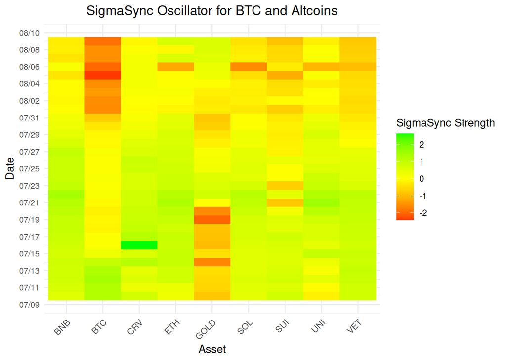

Despite the recent downturns, some assets are showing signs of resilience. Bitcoin has seen a noticeable decline, indicating a bearish trend, while Solana and Ethereum are holding up better, suggesting they might weather the storm more effectively. Gold, often seen as a safe haven, has also faced challenges but is showing hints of recovery. Curve DAO Token stands out due to its extreme fluctuations, which could signal a potential rebound. Other assets like Sui, Binance Coin, VeChain, and Uniswap have shown mixed results, with recent dips but varying degrees of prior strength.

### **Market Thesis – August 10, 2025 Edition**

The U.S. macro environment is evolving in ways that could set the stage for increased volatility and opportunity. The nomination of Christopher Waller and Stephen Morand to the Federal Reserve suggests a possible pivot toward a more forward-looking and accommodative policy stance, with lower interest rates on the horizon if their approach prevails. Markets have yet to fully price in such a regime shift, which leaves room for upside in risk assets, including cryptocurrencies.

### **Conclusion**

As we move into next week, the market thesis is one of cautious optimism. The macro environment, with its potential for Fed policy shifts and increased crypto exposure in retirement funds, sets the stage for continued growth in risk assets. In the crypto market, Bitcoin’s consolidation and the intense long liquidations at $112,250 present a critical juncture, with upside potential towards $125,000 if the price holds, but downside risk if it breaches this level.

This thesis is not just about numbers or technical jargon; it’s about understanding the story the market is telling us. Our extensive research and systematic approach are your guides through this complexity, urging you to stay informed, diversify, and remain cautious. The week ahead is a test of resilience and opportunity, and with the right tools and mindset, you can navigate it with confidence.

*Disclaimer:*

*Parts of this report were developed with the assistance of AI tools (ChatGPT by OpenAI & Grok), used to help articulate insights, structure market observations, and ensure clear communication.*

*The information and analysis provided are for informational and educational purposes only and should not be considered financial, investment, or trading advice.*

*Cryptocurrency markets are highly volatile and subject to rapid price fluctuations, regulatory changes, and unforeseen events. The Efficient Market Hypothesis (EMH) suggests that market prices reflect all available information, making it challenging to consistently outperform the market.*

*Investing or trading in financial markets, especially cryptocurrencies, involves significant risk. There is no guarantee of profits, and you may lose some or all of your invested capital. Past performance is not indicative of future results.*

*You are solely responsible for your financial decisions. Always conduct your own research, consult with a certified financial advisor, and carefully assess your risk tolerance before making any investment decisions.*

*By engaging with our services, you acknowledge and accept these risks.*